# Conditions and Loops

## IF, ELSE and ELIF

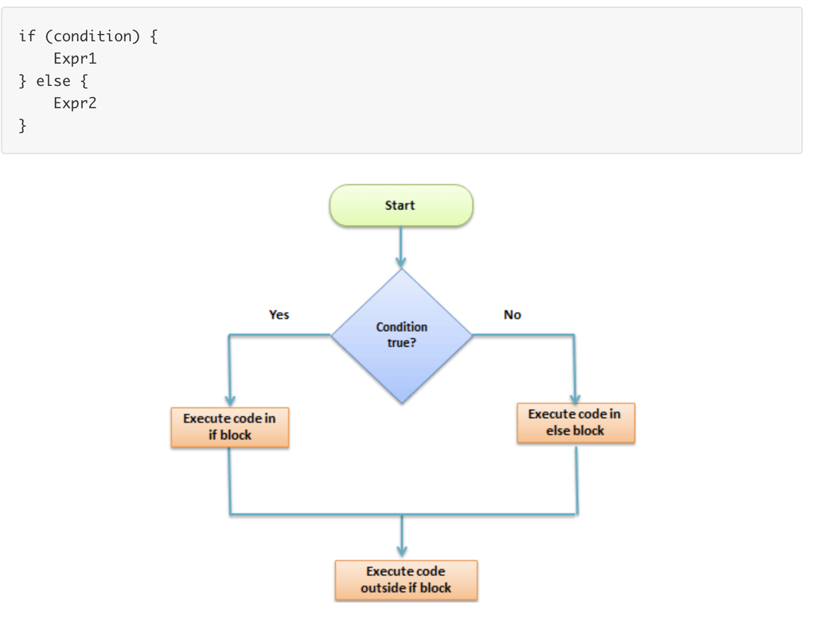

IF-ELSE

```r
# Create vector quantity
quantity <-  55
# Set the is-else statement
if (quantity > 50) {
    print('You sold a lot, did a good job!')
} else {
    print('keep working on!')
}
```

```
## [1] "You sold a lot, did a good job!"
```

Note: Make sure you correctly write the indentations. Code with many conditions can become unreadable when the indentations are not in correct position.

#### Else if statement

We are interested to know if we sold quantities between 40 and 50. If we do, then the print Average day. If quantity is > 50 we print What a great day!, otherwise Not enough for today.

```r
# Create vector quantiy
quantity <-  38
# Create multiple condition statement
if (quantity <40) {
      print('Not enough for today, work harder :(')
} else if (quantity > 40  &quantity <= 50) {
     print('Average day')
} else {
      print('Such a great day!')
}
```

```
## [1] "Not enough for today, work harder :("
```

##### VAT, Products, Categories

A Category would go with Books, Magazine, newspaper etc with 8%; B Category Vegetable,meat, beverage 10%, C Category T-Shirt, jean, pant

```r
category <- 'A'
price <- 25
if (category =='A'){
  cat('A vat rate of 8% is applied.','The total price is',price *1.08)
} else if (category =='B'){
    cat('A vat rate of 10% is applied.','The total price is',price *1.10)
} else {
    cat('A vat rate of 20% is applied.','The total price is',price *1.20)
}
```

```
## A vat rate of 8% is applied. The total price is 27
```

## FOR Loop in R

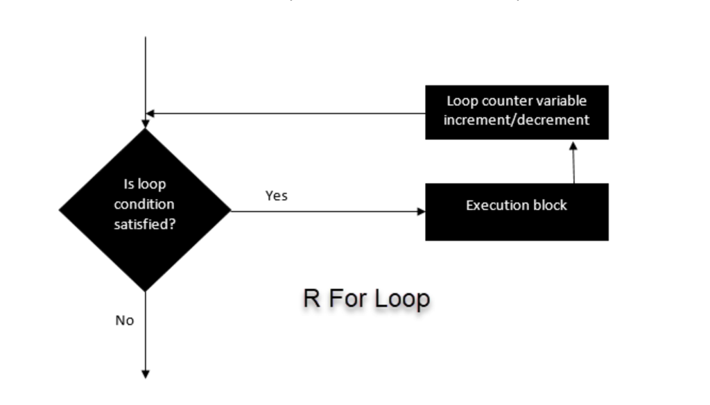

For Loop

Iterate over all the elements of a vector and print the current value

```r
# Create fruit vector
my_brand <- c('Honda', 'Porsche', 'Tesla', 'Mini')
# Create the for statement
for ( i in my_brand){
 print(i)
}
```

```
## [1] "Honda"
## [1] "Porsche"
## [1] "Tesla"
## [1] "Mini"
```

Create a non-linear function by using the polynomial of x between 1 and 4 and we store it in a list

```r
# Create an empty list
list <- c()
# Create a for statement to populate the list
for (i in seq(1, 4, by=1)) {
  list[[i]] <- i*i
}
print(list)
```

```
## [1]  1  4  9 16
```

### Loop over a list

```r
primes <- c(2, 3, 5, 7, 11, 13)

# loop version 1
for (p in primes) {
  print(p)
}
```

```
## [1] 2
## [1] 3
## [1] 5
## [1] 7
## [1] 11
## [1] 13
```

```r
# loop version 2
for (i in 1:length(primes)) {
  print(primes[i])
}
```

```
## [1] 2
## [1] 3
## [1] 5
## [1] 7
## [1] 11
## [1] 13
```

```r
# Create a list with three vectors
Shopping <- list(MiniBasket = c('Beer', 'Diaper', 'Juice', 'Bread'),
Money = c(10, 14, 17), purchase = FALSE)
for (p  in Shopping)
{
    print(p)
}
```

```
## [1] "Beer"   "Diaper" "Juice"  "Bread"
## [1] 10 14 17
## [1] FALSE
```

```r
primes_list <- list(2, 3, 5, 7, 11, 13)

# loop version 1
for (p in primes_list) {
  print(p)
}
```

```
## [1] 2
## [1] 3
## [1] 5
## [1] 7
## [1] 11
## [1] 13
```

```r
# loop version 2
for (i in 1:length(primes_list)) {
  print(primes_list[[i]])
}
```

```
## [1] 2
## [1] 3
## [1] 5
## [1] 7
## [1] 11
## [1] 13
```

Please pay attention to double brackets in version 2

```r
nyc <- list(population = 8405837,
            districts = c("Manhattan", "Bronx", "Brooklyn", "Queens", "Staten Island"),
            capital = FALSE)

# Loop version 1


# Loop version 2
```

### Loop over a matrix

Two for loops needed to iterate over a matrix since it has 2-dimensions, one for rows and one for columns, nested loops!

```r
# Create a matrix
mat <- matrix(data = seq(10, 21, by=1), nrow = 6, ncol =2)
# Create the loop with r and c to iterate over the matrix
for (r in 1:nrow(mat))
    for (c in 1:ncol(mat))
         print(paste("Row", r, "and column",c, "have values of", mat[r,c]))
```

```
## [1] "Row 1 and column 1 have values of 10"
## [1] "Row 1 and column 2 have values of 16"
## [1] "Row 2 and column 1 have values of 11"
## [1] "Row 2 and column 2 have values of 17"
## [1] "Row 3 and column 1 have values of 12"
## [1] "Row 3 and column 2 have values of 18"
## [1] "Row 4 and column 1 have values of 13"
## [1] "Row 4 and column 2 have values of 19"
## [1] "Row 5 and column 1 have values of 14"
## [1] "Row 5 and column 2 have values of 20"
## [1] "Row 6 and column 1 have values of 15"
## [1] "Row 6 and column 2 have values of 21"
```

```r
linkedin <- c(16, 9, 13, 5, 2, 17, 14)

# Code the for loop with conditionals
for (li in linkedin) {
  if (li > 11) {
    print("I guess you're kind of popular!")
  } else {
    print("Be more visible!")
  }
  print(li)
}
```

```
## [1] "I guess you're kind of popular!"
## [1] 16
## [1] "Be more visible!"
## [1] 9
## [1] "I guess you're kind of popular!"
## [1] 13
## [1] "Be more visible!"
## [1] 5
## [1] "Be more visible!"
## [1] 2
## [1] "I guess you're kind of popular!"
## [1] 17
## [1] "I guess you're kind of popular!"
## [1] 14
```

#### How to break?

The ‘break’ statement abandons the active loop: the remaining code in the loop is skipped and the loop is not iterated over anymore.  
The ‘next’ statement skips the remainder of the code in the loop, but continues the iteration.

Use previous linkedin list.  
If the vector element’s value exceeds 16, print out “This is ridiculous, I’m outta here!” and have R abandon the for loop (break).  
If the value is lower than 5, print out “This is too embarrassing!” and fast-forward to the next iteration (next).

#### Practice For Loop

Can you write code that counts the number of u’s that come before the first x in tweet? tweet <- “Without data, you are just another person with an opinion!” #E. Deming chars <- strsplit(tweet, split = “”)[[1]]

### WHILE Loop

A loop is a statement that keeps running until a condition is satisfied. The syntax for a while loop is the following:

Note: Remember to write a closing condition at some point otherwise the loop will go on indefinitely.

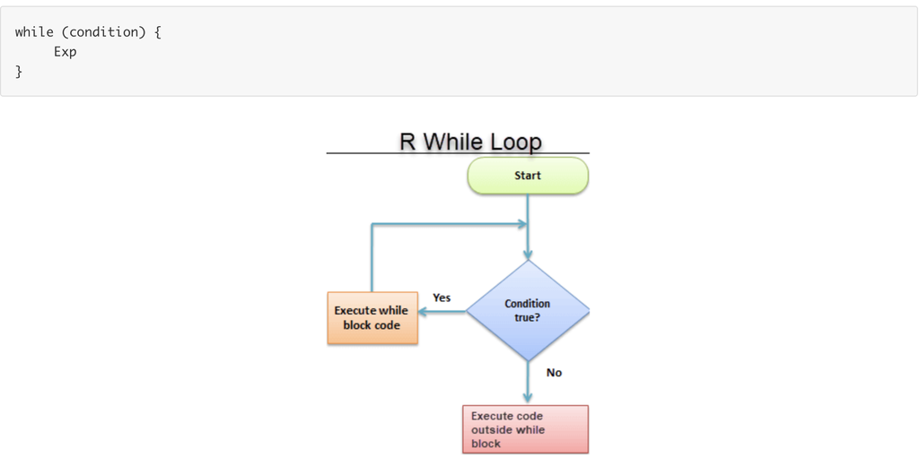

WHILE

```r
#Create a variable with value 1
begin <- 1

#Create the loop
while (begin <= 10){

#See which we are
cat('This is loop number',begin)

#add 1 to the variable begin after each loop
begin <- begin+1
print(begin)
}
```

```
## This is loop number 1[1] 2
## This is loop number 2[1] 3
## This is loop number 3[1] 4
## This is loop number 4[1] 5
## This is loop number 5[1] 6
## This is loop number 6[1] 7
## This is loop number 7[1] 8
## This is loop number 8[1] 9
## This is loop number 9[1] 10
## This is loop number 10[1] 11
```

Exercise 1: Code a while loop with the following characteristics:  
Initialize the speed (i.e. 60)  
The condition of the while loop should check if speed is higher than 30.  
Inside the body of the while loop, print out “Slow down!”.  
Inside the body of the while loop, decrease the speed by 7 units. This step is crucial; otherwise your while loop will never stop.

Exercise 2: If the speed is greater than 48, have R print out “Slow down big time!”, and decrease the speed by 11.  
Otherwise, have R simply print out “Slow down!”, and decrease the speed by 6.

Exercise 3: (Break)  
Refine the while loop such that it is abandoned when the speed of the vehicle is greater than 80. This time, the speed variable should be initialized to 88; keep it that way.

Exercise 4: Wrap it up  
In a While loop, print the triple of i, so 3 * i, at each run.  
is abandoned with a break if the triple of i is divisible by 8, but still prints out this triple before breaking.

Exercise 5: We bought a stock for 50$. If the price goes below 45, we want to short it. Else, keep it in portfolio. The price can fluctuate between -10 to +10 around 50 after each loop.

Answer for break and next:

```r
linkedin <- c(16, 9, 13, 5, 2, 17, 14)

# Adapt the for loop
for (li in linkedin) {
  if (li > 10) {
    print("You're kinda popular!")
  } else {
    print("Be more visible!")
  }

  # Add if statement with break
  if (li > 16) {
    print("This is ridiculous, I'm outta here!")
    break
  }

  # Add if statement with next
  if (li < 5) {
    print("This is too embarrassing!")
    next
  }

  print(li)
}
```

```
## [1] "You're kinda popular!"
## [1] 16
## [1] "Be more visible!"
## [1] 9
## [1] "You're kinda popular!"
## [1] 13
## [1] "Be more visible!"
## [1] 5
## [1] "Be more visible!"
## [1] "This is too embarrassing!"
## [1] "You're kinda popular!"
## [1] "This is ridiculous, I'm outta here!"
```